# Case técnico

Gustavo Cardoso

2026-02-27

## 1. Leitura e Consolidação dos Dados

Conforme as instruções, os arquivos de input originais foram mantidos inalterados. O processo de consolidação e limpeza ocorre inteiramente via código.

```r
# Lendo os arquivos originais
arquivos <- list.files(pattern = "\\.xlsx$")

df_arquivos <- data.frame(nome_original = arquivos) %>%
  mutate(
    data_texto = str_extract(nome_original, "^\\w+\\s\\d{4}"),
    data_formatada = my(data_texto)
  ) %>%
  arrange(data_formatada)

# Função para ler cada arquivo e transformar o serial em Data
ler_e_limpar <- function(caminho) {
  tabela_temporaria <- read_excel(caminho)
  tabela_temporaria[[1]] <- as.Date(as.numeric(tabela_temporaria[[1]]), origin = "1899-12-30")
  tabela_temporaria$Arquivo_Fonte <- caminho
  return(tabela_temporaria)
}

# Consolidação
dados_finais <- df_arquivos$nome_original %>%
  map_df(~ ler_e_limpar(.x))

# Limpeza e tipagem correta das colunas
dados_finais_limpos <- dados_finais %>%
  mutate(
    Data_Correta = as.Date(.[[1]]),
    Preco_Num = as.numeric(.[[2]])
  ) %>%
  filter(!is.na(Preco_Num))

# Exportando o resultado final para planilha (Requisito do Case)
write_xlsx(dados_finais_limpos, "dados_consolidados_cobre.xlsx")
```

## 2. Respostas às Questões

### Questões 1 e 2: Extremos de Cotação

```r
# Menor Cotação
min_data <- dados_finais_limpos[which.min(dados_finais_limpos$Preco_Num), ]
cat("Menor cotação:", min_data$Preco_Num, "em", format(min_data$Data_Correta, "%d/%m/%Y"), "\n")
```

```
## Menor cotação: 4617.5 em 23/03/2020
```

```r
# Maior Cotação
max_data <- dados_finais_limpos[which.max(dados_finais_limpos$Preco_Num), ]
cat("Maior cotação:", max_data$Preco_Num, "em", format(max_data$Data_Correta, "%d/%m/%Y"))
```

```
## Maior cotação: 12510 em 30/12/2025
```

### Questão 3: Variação Média Mensal (2020 e 2024)

```r
variacao_mensal <- dados_finais_limpos %>%
  mutate(MesAno = floor_date(Data_Correta, "month")) %>%
  group_by(MesAno) %>%
  summarise(Preco_Medio = mean(Preco_Num, na.rm = TRUE)) %>%
  mutate(Variacao = (Preco_Medio / lag(Preco_Medio) - 1))

media_2020 <- mean(variacao_mensal$Variacao[year(variacao_mensal$MesAno) == 2020], na.rm = TRUE)
media_2024 <- mean(variacao_mensal$Variacao[year(variacao_mensal$MesAno) == 2024], na.rm = TRUE)

cat("Média 2020:", scales::percent(media_2020, accuracy = 0.01), "\n")
```

```
## Média 2020: 2.47%
```

```r
cat("Média 2024:", scales::percent(media_2024, accuracy = 0.01))
```

```
## Média 2024: 0.61%
```

### Questão 4: Variação Acumulada

```r
preco_inicial <- head(dados_finais_limpos$Preco_Num, 1)
preco_final <- tail(dados_finais_limpos$Preco_Num, 1)
var_total <- (preco_final / preco_inicial - 1)

cat("Variação Acumulada (Jan/2020 a Dez/2025):", scales::percent(var_total, accuracy = 0.01))
```

```
## Variação Acumulada (Jan/2020 a Dez/2025): 82.97%
```

## 3. Visualizações

### Questão 5: Evolução do Preço Médio Mensal

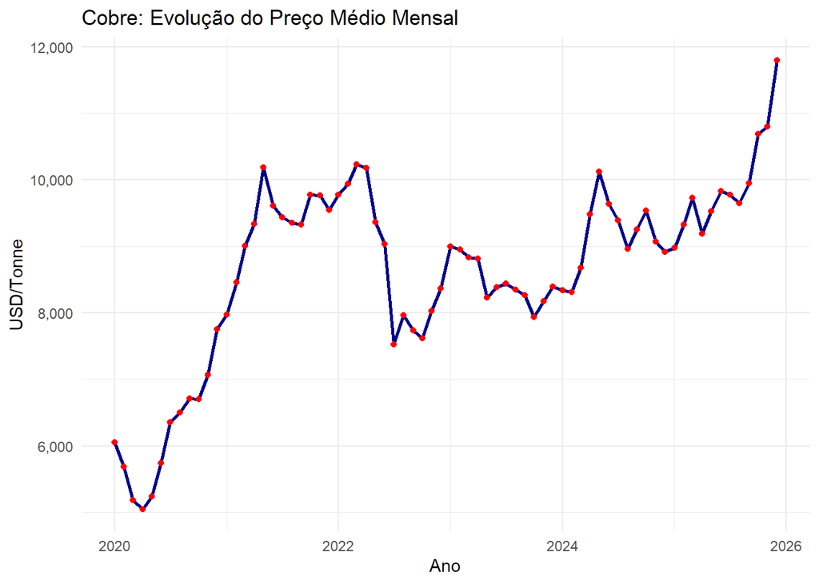

```r
ggplot(variacao_mensal, aes(x = MesAno, y = Preco_Medio)) +
  geom_line(color = "darkblue", size = 1) +
  geom_point(color = "red", size = 1.5) +
  scale_y_continuous(labels = scales::comma) +
  labs(title = "Cobre: Evolução do Preço Médio Mensal", x = "Ano", y = "USD/Tonne") +
  theme_minimal()
```

### Questão 6: Fechamento Trimestral

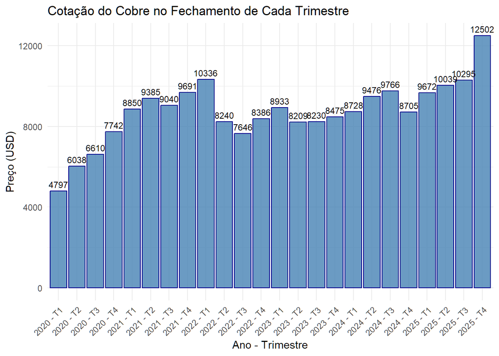

```r
dados_trimestrais <- dados_finais_limpos %>%
  mutate(Trim_Label = paste0(year(Data_Correta), " - T", quarter(Data_Correta))) %>%
  group_by(Trim_Label) %>%
  filter(Data_Correta == max(Data_Correta)) %>%
  ungroup() %>%
  arrange(Data_Correta) %>%
  mutate(Trim_Label = factor(Trim_Label, levels = Trim_Label))

ggplot(dados_trimestrais, aes(x = Trim_Label, y = Preco_Num)) +
  geom_col(fill = "steelblue", color = "darkblue", alpha = 0.8) +
  geom_text(aes(label = round(Preco_Num, 0)), vjust = -0.5, size = 3) +
  labs(title = "Cotação do Cobre no Fechamento de Cada Trimestre", x = "Ano - Trimestre", y = "Preço (USD)") +
  theme_minimal() +
  theme(axis.text.x = element_text(angle = 45, hjust = 1))
```

### Questão 7: Variação Anual Média

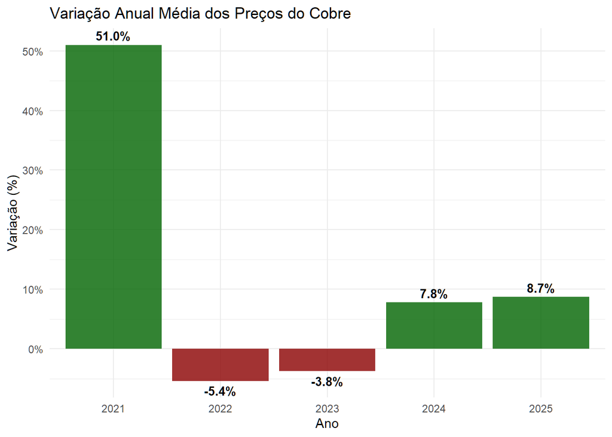

```r
resumo_anual <- variacao_mensal %>%
  group_by(Ano = year(MesAno)) %>%
  summarise(Media_Anual = mean(Preco_Medio, na.rm = TRUE)) %>%
  mutate(Var_Anual = (Media_Anual / lag(Media_Anual) - 1)) %>%
  filter(Ano != 2020)

ggplot(resumo_anual, aes(x = factor(Ano), y = Var_Anual)) +
  geom_col(fill = ifelse(resumo_anual$Var_Anual > 0, "darkgreen", "darkred"), alpha = 0.8) +
  geom_text(aes(label = scales::percent(Var_Anual, accuracy = 0.1)),
            vjust = ifelse(resumo_anual$Var_Anual > 0, -0.5, 1.5), size = 3.5, fontface = "bold") +
  scale_y_continuous(labels = scales::percent) +
  labs(title = "Variação Anual Média dos Preços do Cobre", x = "Ano", y = "Variação (%)") +
  theme_minimal()
```

## 4. Análise Sintética (Questão 8)

A trajetória dos preços do cobre entre 2020 e 2025 foi marcada por uma forte volatilidade inicial, seguida por um ciclo de valorização estrutural. No início de 2020, a pandemia de covid-19 provocou uma severa contração da demanda global, levando as cotações ao seu patamar mínimo no período (próximo a US$ 4.600 no mês de março). Já no ano de 2021, com a recuperação em marcha na maioria das economias, o preço teve uma apreciação notável. Em contrapartida, as pressões inflacionárias a partir de 2022 e a instabilidade do mercado imobiliário chinês, maior consumidor global do produto, atuaram para trazer os preços para patamares mais baixos.

Por fim, a partir de 2024 inicia-se uma tendência que se consolida no ano seguinte (atingindo o pico histórico acima de US$ 12.500), que é uma valorização acentuada do cobre. A razão para isto pode ser explicada pela importância que o componente tem para os setores ligados à transição energética e à própria cadeia de suprimentos das novas tecnologias de inteligência artificial e robótica. Além disso, a oferta global apresenta limites devido à restrição de minas de extração de cobre, uma circunstância que traz implicações econômicas e geopolíticas.